# Project: Soccer Data Analysis

### Data Cleaning

Based on the first data loaded in the previous cell, I will merge it with the other two data, which contains the player's attribute, birthday, height, weight, player's overall rating, potential, and team names. According to the initial interest, I will then extract age and names for players who recorded a goal or assist from the merged data. Lastly, I will calculate the goal point, which is home_team_goal - away_team_goal.

```python
df.shape
```

```
(25979, 115)
```

```python
df = df[[
    'season', 'date', 'home_team_api_id', 'away_team_api_id', 'home_team_goal',
    'away_team_goal', 'home_player_1', 'home_player_2', 'home_player_3',
    'home_player_4', 'home_player_5', 'home_player_6', 'home_player_7',
    'home_player_8', 'home_player_9', 'home_player_10', 'home_player_11',
    'away_player_1', 'away_player_2', 'away_player_3', 'away_player_4',
    'away_player_5', 'away_player_6', 'away_player_7', 'away_player_8',
    'away_player_9', 'away_player_10', 'away_player_11', 'goal'
]]
```

```python
df.head()
```

|  | season | date | home_team_api_id | away_team_api_id | home_team_goal | away_team_goal | home_player_1 | home_player_2 | home_player_3 | home_player_4 | home_player_5 | home_player_6 | home_player_7 | home_player_8 | home_player_9 | home_player_10 | home_player_11 | away_player_1 | away_player_2 | away_player_3 | away_player_4 | away_player_5 | away_player_6 | away_player_7 | away_player_8 | away_player_9 | away_player_10 | away_player_11 | goal |
| --- | --- | --- | --- | --- | --- | --- | --- | --- | --- | --- | --- | --- | --- | --- | --- | --- | --- | --- | --- | --- | --- | --- | --- | --- | --- | --- | --- | --- | --- |
| 0 | 2008/2009 | 2008-08-17 00:00:00 | 9987 | 9993 | 1 | 1 | NaN | NaN | NaN | NaN | NaN | NaN | NaN | NaN | NaN | NaN | NaN | NaN | NaN | NaN | NaN | NaN | NaN | NaN | NaN | NaN | NaN | NaN | NaN |
| 1 | 2008/2009 | 2008-08-16 00:00:00 | 10000 | 9994 | 0 | 0 | NaN | NaN | NaN | NaN | NaN | NaN | NaN | NaN | NaN | NaN | NaN | NaN | NaN | NaN | NaN | NaN | NaN | NaN | NaN | NaN | NaN | NaN | NaN |
| 2 | 2008/2009 | 2008-08-16 00:00:00 | 9984 | 8635 | 0 | 3 | NaN | NaN | NaN | NaN | NaN | NaN | NaN | NaN | NaN | NaN | NaN | NaN | NaN | NaN | NaN | NaN | NaN | NaN | NaN | NaN | NaN | NaN | NaN |
| 3 | 2008/2009 | 2008-08-17 00:00:00 | 9991 | 9998 | 5 | 0 | NaN | NaN | NaN | NaN | NaN | NaN | NaN | NaN | NaN | NaN | NaN | NaN | NaN | NaN | NaN | NaN | NaN | NaN | NaN | NaN | NaN | NaN | NaN |
| 4 | 2008/2009 | 2008-08-16 00:00:00 | 7947 | 9985 | 1 | 3 | NaN | NaN | NaN | NaN | NaN | NaN | NaN | NaN | NaN | NaN | NaN | NaN | NaN | NaN | NaN | NaN | NaN | NaN | NaN | NaN | NaN | NaN | NaN |

```python
df.dropna(inplace = True)
```

```python
df.shape
```

```
(13325, 29)
```

```python
df = df.sort_values('date').reset_index(drop = True)
```

```python
df.head()
```

|  | season | date | home_team_api_id | away_team_api_id | home_team_goal | away_team_goal | home_player_1 | home_player_2 | home_player_3 | home_player_4 | home_player_5 | home_player_6 | home_player_7 | home_player_8 | home_player_9 | home_player_10 | home_player_11 | away_player_1 | away_player_2 | away_player_3 | away_player_4 | away_player_5 | away_player_6 | away_player_7 | away_player_8 | away_player_9 | away_player_10 | away_player_11 | goal |
| --- | --- | --- | --- | --- | --- | --- | --- | --- | --- | --- | --- | --- | --- | --- | --- | --- | --- | --- | --- | --- | --- | --- | --- | --- | --- | --- | --- | --- | --- |
| 0 | 2008/2009 | 2008-08-15 00:00:00 | 9823 | 9790 | 2 | 2 | 27284.0 | 35988.0 | 39774.0 | 33085.0 | 30894.0 | 38244.0 | 30872.0 | 38843.0 | 95078.0 | 30638.0 | 32118.0 | 25524.0 | 36183.0 | 27293.0 | 37787.0 | 37156.0 | 30749.0 | 30598.0 | 39106.0 | 38216.0 | 33101.0 | 30764.0 | <goal><value><comment>n</comment><stats><goals... |
| 1 | 2008/2009 | 2008-08-16 00:00:00 | 9825 | 8659 | 1 | 0 | 23686.0 | 26111.0 | 38835.0 | 30986.0 | 31291.0 | 31013.0 | 30935.0 | 39297.0 | 26181.0 | 30960.0 | 36410.0 | 36373.0 | 36832.0 | 23115.0 | 37280.0 | 24728.0 | 24664.0 | 31088.0 | 23257.0 | 24171.0 | 25922.0 | 27267.0 | <goal><value><comment>n</comment><stats><goals... |
| 2 | 2008/2009 | 2008-08-16 00:00:00 | 8472 | 8650 | 0 | 1 | 32562.0 | 38836.0 | 24446.0 | 24408.0 | 36786.0 | 38802.0 | 24655.0 | 17866.0 | 30352.0 | 23927.0 | 24410.0 | 30660.0 | 37442.0 | 30617.0 | 24134.0 | 414792.0 | 37139.0 | 30618.0 | 40701.0 | 24800.0 | 24635.0 | 30853.0 | <goal><value><comment>n</comment><stats><goals... |
| 3 | 2008/2009 | 2008-08-16 00:00:00 | 8654 | 8528 | 2 | 1 | 36374.0 | 30966.0 | 23818.0 | 37277.0 | 30687.0 | 36394.0 | 37169.0 | 24223.0 | 24773.0 | 34543.0 | 23139.0 | 34421.0 | 34987.0 | 35472.0 | 111865.0 | 25005.0 | 35327.0 | 25150.0 | 97988.0 | 41877.0 | 127857.0 | 34466.0 | <goal><value><comment>n</comment><stats><goals... |
| 4 | 2008/2009 | 2008-08-16 00:00:00 | 8668 | 8655 | 2 | 3 | 31465.0 | 30371.0 | 24004.0 | 33086.0 | 30857.0 | 24011.0 | 109058.0 | 23268.0 | 24846.0 | 24006.0 | 24160.0 | 30622.0 | 37764.0 | 19020.0 | 23921.0 | 24136.0 | 30342.0 | 23889.0 | 23916.0 | 23922.0 | 34176.0 | 30646.0 | <goal><value><comment>n</comment><stats><goals... |

```python
# extract player_id who recorded goal or assist

df['goal_player_id'] = df.goal.str.extract('(1>[0-9]{5,6})', expand = True)
df['goal_player_id'] = df['goal_player_id'].astype(str).str[2:]
df['goal_player_id'] = df['goal_player_id'].replace('n', np.NaN)
df['goal_player_id'] = pd.to_numeric(df['goal_player_id'])

df['assist_player_id'] = df.goal.str.extract('(2>[0-9]{5,6})', expand = True)
df['assist_player_id'] = df['assist_player_id'].astype(str).str[2:]
df['assist_player_id'] = df['assist_player_id'].replace('n', np.NaN)
df['assist_player_id'] = pd.to_numeric(df['assist_player_id'])

df.drop(columns = ['goal'], inplace = True)
```

```python
df.head()
```

|  | season | date | home_team_api_id | away_team_api_id | home_team_goal | away_team_goal | home_player_1 | home_player_2 | home_player_3 | home_player_4 | home_player_5 | home_player_6 | home_player_7 | home_player_8 | home_player_9 | home_player_10 | home_player_11 | away_player_1 | away_player_2 | away_player_3 | away_player_4 | away_player_5 | away_player_6 | away_player_7 | away_player_8 | away_player_9 | away_player_10 | away_player_11 | goal_player_id | … |
| --- | --- | --- | --- | --- | --- | --- | --- | --- | --- | --- | --- | --- | --- | --- | --- | --- | --- | --- | --- | --- | --- | --- | --- | --- | --- | --- | --- | --- | --- | --- |
| 0 | 2008/2009 | 2008-08-15 00:00:00 | 9823 | 9790 | 2 | 2 | 27284.0 | 35988.0 | 39774.0 | 33085.0 | 30894.0 | 38244.0 | 30872.0 | 38843.0 | 95078.0 | 30638.0 | 32118.0 | 25524.0 | 36183.0 | 27293.0 | 37787.0 | 37156.0 | 30749.0 | 30598.0 | 39106.0 | 38216.0 | 33101.0 | 30764.0 | 30872.0 | … |
| 1 | 2008/2009 | 2008-08-16 00:00:00 | 9825 | 8659 | 1 | 0 | 23686.0 | 26111.0 | 38835.0 | 30986.0 | 31291.0 | 31013.0 | 30935.0 | 39297.0 | 26181.0 | 30960.0 | 36410.0 | 36373.0 | 36832.0 | 23115.0 | 37280.0 | 24728.0 | 24664.0 | 31088.0 | 23257.0 | 24171.0 | 25922.0 | 27267.0 | 26181.0 | … |
| 2 | 2008/2009 | 2008-08-16 00:00:00 | 8472 | 8650 | 0 | 1 | 32562.0 | 38836.0 | 24446.0 | 24408.0 | 36786.0 | 38802.0 | 24655.0 | 17866.0 | 30352.0 | 23927.0 | 24410.0 | 30660.0 | 37442.0 | 30617.0 | 24134.0 | 414792.0 | 37139.0 | 30618.0 | 40701.0 | 24800.0 | 24635.0 | 30853.0 | 30853.0 | … |
| 3 | 2008/2009 | 2008-08-16 00:00:00 | 8654 | 8528 | 2 | 1 | 36374.0 | 30966.0 | 23818.0 | 37277.0 | 30687.0 | 36394.0 | 37169.0 | 24223.0 | 24773.0 | 34543.0 | 23139.0 | 34421.0 | 34987.0 | 35472.0 | 111865.0 | 25005.0 | 35327.0 | 25150.0 | 97988.0 | 41877.0 | 127857.0 | 34466.0 | 23139.0 | … |
| 4 | 2008/2009 | 2008-08-16 00:00:00 | 8668 | 8655 | 2 | 3 | 31465.0 | 30371.0 | 24004.0 | 33086.0 | 30857.0 | 24011.0 | 109058.0 | 23268.0 | 24846.0 | 24006.0 | 24160.0 | 30622.0 | 37764.0 | 19020.0 | 23921.0 | 24136.0 | 30342.0 | 23889.0 | 23916.0 | 23922.0 | 34176.0 | 30646.0 | 30342.0 | … |

```python
# merge team_long_name for home and away team each

df_team = pd.read_csv('Team.csv')
df_team.drop(columns = ['id', 'team_fifa_api_id', 'team_short_name'], inplace = True)
df_team.head()
```

|  | team_api_id | team_long_name |
| --- | --- | --- |
| 0 | 9987 | KRC Genk |
| 1 | 9993 | Beerschot AC |
| 2 | 10000 | SV Zulte-Waregem |
| 3 | 9994 | Sporting Lokeren |
| 4 | 9984 | KSV Cercle Brugge |

```python
df_team.nunique()
```

```
team_api_id       299
team_long_name    296
dtype: int64
```

```python
df_home = df_team.copy()
df_away = df_team.copy()
```

```python
# remane column names for merging

df_home = df_home.rename(columns = {'team_api_id' : 'home_team_api_id', 'team_long_name' : 'home_team_name'})
df_home.head()
```

|  | home_team_api_id | home_team_name |
| --- | --- | --- |
| 0 | 9987 | KRC Genk |
| 1 | 9993 | Beerschot AC |
| 2 | 10000 | SV Zulte-Waregem |
| 3 | 9994 | Sporting Lokeren |
| 4 | 9984 | KSV Cercle Brugge |

```python
df_away = df_team.rename(columns = {'team_api_id' : 'away_team_api_id', 'team_long_name' : 'away_team_name'})
df_away.head()
```

|  | away_team_api_id | away_team_name |
| --- | --- | --- |
| 0 | 9987 | KRC Genk |
| 1 | 9993 | Beerschot AC |
| 2 | 10000 | SV Zulte-Waregem |
| 3 | 9994 | Sporting Lokeren |
| 4 | 9984 | KSV Cercle Brugge |

```python
df = pd.merge(df, df_home, how = 'inner')
df = pd.merge(df, df_away, how = 'inner')

# pd.merge(df, df_copy, left_on = 'home_team_api_id', right_on = 'team_api_id')
```

```python
df.shape
```

```
(13325, 32)
```

```python
# merge goal_player's name and physical record
# merge assist_player's name and physical record

df_player = pd.read_csv('Player.csv')
df_player.drop(columns = ['id', 'player_fifa_api_id'], inplace = True)
```

```python
df_player.head()
```

|  | player_api_id | player_name | birthday | height | weight |
| --- | --- | --- | --- | --- | --- |
| 0 | 505942 | Aaron Appindangoye | 1992-02-29 00:00:00 | 182.88 | 187 |
| 1 | 155782 | Aaron Cresswell | 1989-12-15 00:00:00 | 170.18 | 146 |
| 2 | 162549 | Aaron Doran | 1991-05-13 00:00:00 | 170.18 | 163 |
| 3 | 30572 | Aaron Galindo | 1982-05-08 00:00:00 | 182.88 | 198 |
| 4 | 23780 | Aaron Hughes | 1979-11-08 00:00:00 | 182.88 | 154 |

```python
df_goal = df_player.copy()
df_assist = df_player.copy()
```

```python
df_goal = df_goal.rename(columns = {'player_api_id' : 'goal_player_id',
                                    'player_name':'goal_player_name',
                                    'birthday':'goal_birthday',
                                    'height':'goal_height',
                                    'weight':'goal_weight'})
df_goal.head()
```

|  | goal_player_id | goal_player_name | goal_birthday | goal_height | goal_weight |
| --- | --- | --- | --- | --- | --- |
| 0 | 505942 | Aaron Appindangoye | 1992-02-29 00:00:00 | 182.88 | 187 |
| 1 | 155782 | Aaron Cresswell | 1989-12-15 00:00:00 | 170.18 | 146 |
| 2 | 162549 | Aaron Doran | 1991-05-13 00:00:00 | 170.18 | 163 |
| 3 | 30572 | Aaron Galindo | 1982-05-08 00:00:00 | 182.88 | 198 |
| 4 | 23780 | Aaron Hughes | 1979-11-08 00:00:00 | 182.88 | 154 |

```python
df_assist = df_assist.rename(columns = {'player_api_id' : 'assist_player_id',
                                        'player_name':'assist_player_name',
                                        'birthday':'assist_birthday',
                                        'height':'assist_height',
                                        'weight':'assist_weight'})
df_assist.head()
```

|  | assist_player_id | assist_player_name | assist_birthday | assist_height | assist_weight |
| --- | --- | --- | --- | --- | --- |
| 0 | 505942 | Aaron Appindangoye | 1992-02-29 00:00:00 | 182.88 | 187 |
| 1 | 155782 | Aaron Cresswell | 1989-12-15 00:00:00 | 170.18 | 146 |
| 2 | 162549 | Aaron Doran | 1991-05-13 00:00:00 | 170.18 | 163 |
| 3 | 30572 | Aaron Galindo | 1982-05-08 00:00:00 | 182.88 | 198 |
| 4 | 23780 | Aaron Hughes | 1979-11-08 00:00:00 | 182.88 | 154 |

```python
df.shape
```

```
(13325, 32)
```

```python
df = pd.merge(df, df_goal, how = 'inner')
df = pd.merge(df, df_assist, how = 'inner')
```

```python
df.shape
```

```
(7173, 40)
```

```python
df.isnull().sum()
```

```
season                0
date                  0
home_team_api_id      0
away_team_api_id      0
home_team_goal        0
away_team_goal        0
home_player_1         0
home_player_2         0
home_player_3         0
home_player_4         0
home_player_5         0
home_player_6         0
home_player_7         0
home_player_8         0
home_player_9         0
home_player_10        0
home_player_11        0
away_player_1         0
away_player_2         0
away_player_3         0
away_player_4         0
away_player_5         0
away_player_6         0
away_player_7         0
away_player_8         0
away_player_9         0
away_player_10        0
away_player_11        0
goal_player_id        0
assist_player_id      0
home_team_name        0
away_team_name        0
goal_player_name      0
goal_birthday         0
goal_height           0
goal_weight           0
assist_player_name    0
assist_birthday       0
assist_height         0
assist_weight         0
dtype: int64
```

```python
# merge goal_player's overall rating and potential
# merge assist_player's overall rating and potential

df_att = pd.read_csv('Player_Attributes.csv')
```

```python
df_att = df_att[['player_api_id', 'overall_rating', 'potential']]
df_att.sample(10)
```

|  | player_api_id | overall_rating | potential |
| --- | --- | --- | --- |
| 83400 | 22929 | 72.0 | 75.0 |
| 54490 | 165709 | 74.0 | 84.0 |
| 96959 | 302696 | 64.0 | 74.0 |
| 92080 | 45245 | 64.0 | 66.0 |
| 87563 | 56952 | 73.0 | 73.0 |
| 121742 | 111865 | 76.0 | 77.0 |
| 58768 | 27663 | 74.0 | 74.0 |
| 56602 | 23986 | 69.0 | 70.0 |
| 38416 | 17600 | 65.0 | 70.0 |
| 101008 | 248150 | 57.0 | 67.0 |

```python
df_att_goal = df_att.copy()
df_att_assist = df_att.copy()
```

```python
df_att_goal = df_att_goal.rename(columns = {'player_api_id' : 'goal_player_id',
                                            'overall_rating':'goal_overall_rating',
                                            'potential':'goal_potential'})
df_att_goal.head()
```

|  | goal_player_id | goal_overall_rating | goal_potential |
| --- | --- | --- | --- |
| 0 | 505942 | 67.0 | 71.0 |
| 1 | 505942 | 67.0 | 71.0 |
| 2 | 505942 | 62.0 | 66.0 |
| 3 | 505942 | 61.0 | 65.0 |
| 4 | 505942 | 61.0 | 65.0 |

```python
df_att_assist = df_att_assist.rename(columns = {'player_api_id' : 'assist_player_id',
                                                'overall_rating':'assist_overall_rating',
                                                'potential':'assist_potential'})
df_att_assist.head()
```

|  | assist_player_id | assist_overall_rating | assist_potential |
| --- | --- | --- | --- |
| 0 | 505942 | 67.0 | 71.0 |
| 1 | 505942 | 67.0 | 71.0 |
| 2 | 505942 | 62.0 | 66.0 |
| 3 | 505942 | 61.0 | 65.0 |
| 4 | 505942 | 61.0 | 65.0 |

```python
df_att_goal = df_att_goal.groupby('goal_player_id').mean().reset_index()
df_att_assist = df_att_assist.groupby('assist_player_id').mean().reset_index()
```

```python
df.shape
```

```
(7173, 40)
```

```python
df = pd.merge(df, df_att_goal, how = 'inner')
df = pd.merge(df, df_att_assist, how = 'inner')
```

```python
df.shape
```

```
(7173, 44)
```

```python
df['goal_point'] = np.abs(df['home_team_goal'] - df['away_team_goal'])
```

```python
# Calculate win or loss and then put the result into new column

df.loc[df['home_team_goal'] - df['away_team_goal'] == 0, 'match_winner_team'] = 'draw'
df.loc[df['home_team_goal'] - df['away_team_goal'] > 0, 'match_winner_team'] = df['home_team_name']
df.loc[df['home_team_goal'] - df['away_team_goal'] < 0, 'match_winner_team'] = df['away_team_name']

df.loc[df['home_team_goal'] - df['away_team_goal'] == 0, 'win_location'] = 'draw'
df.loc[df['home_team_goal'] - df['away_team_goal'] > 0, 'win_location'] = 'home win'
df.loc[df['home_team_goal'] - df['away_team_goal'] < 0, 'win_location'] = 'away win'
```

```python
# Calculate goal or assist player's ages and then put the result into new column

df['goal_player_age'] = pd.to_datetime(df.date).dt.year - pd.to_datetime(df.goal_birthday).dt.year
df['assist_player_age'] = pd.to_datetime(df.date).dt.year - pd.to_datetime(df.assist_birthday).dt.year
```

```python
df.columns.values
```

```
array(['season', 'date', 'home_team_api_id', 'away_team_api_id',
       'home_team_goal', 'away_team_goal', 'home_player_1',
       'home_player_2', 'home_player_3', 'home_player_4', 'home_player_5',
       'home_player_6', 'home_player_7', 'home_player_8', 'home_player_9',
       'home_player_10', 'home_player_11', 'away_player_1',
       'away_player_2', 'away_player_3', 'away_player_4', 'away_player_5',
       'away_player_6', 'away_player_7', 'away_player_8', 'away_player_9',
       'away_player_10', 'away_player_11', 'goal_player_id',
       'assist_player_id', 'home_team_name', 'away_team_name',
       'goal_player_name', 'goal_birthday', 'goal_height', 'goal_weight',
       'assist_player_name', 'assist_birthday', 'assist_height',
       'assist_weight', 'goal_overall_rating', 'goal_potential',
       'assist_overall_rating', 'assist_potential', 'goal_point',
       'match_winner_team', 'win_location', 'goal_player_age',
       'assist_player_age'], dtype=object)
```

```python
df = df[['season','home_team_name', 'away_team_name','home_team_goal', 'away_team_goal','goal_point','match_winner_team', 'win_location',
    'goal_player_name', 'goal_player_age', 'goal_height', 'goal_weight', 'goal_overall_rating', 'goal_potential',
    'assist_player_name', 'assist_player_age', 'assist_height', 'assist_weight', 'assist_overall_rating', 'assist_potential','home_player_1',
       'home_player_2', 'home_player_3', 'home_player_4', 'home_player_5',
       'home_player_6', 'home_player_7', 'home_player_8', 'home_player_9',
       'home_player_10', 'home_player_11', 'away_player_1',
       'away_player_2', 'away_player_3', 'away_player_4', 'away_player_5',
       'away_player_6', 'away_player_7', 'away_player_8', 'away_player_9',
       'away_player_10', 'away_player_11']]
```

```python
df = df.sort_values(['season']).reset_index(drop = True)
```

```python
df.shape
```

```
(7173, 42)
```

## Exploratory Data Analysis

```python
df.describe()
```

|  | home_team_goal | away_team_goal | goal_point | goal_player_age | goal_height | goal_weight | goal_overall_rating | goal_potential | assist_player_age | assist_height | assist_weight | assist_overall_rating | assist_potential | home_player_1 | home_player_2 | home_player_3 | home_player_4 | home_player_5 | home_player_6 | home_player_7 | home_player_8 | home_player_9 | home_player_10 | home_player_11 | away_player_1 | away_player_2 | away_player_3 | away_player_4 | away_player_5 | … |
| --- | --- | --- | --- | --- | --- | --- | --- | --- | --- | --- | --- | --- | --- | --- | --- | --- | --- | --- | --- | --- | --- | --- | --- | --- | --- | --- | --- | --- | --- | --- |
| count | 7173.000000 | 7173.000000 | 7173.000000 | 7173.000000 | 7173.000000 | 7173.000000 | 7173.000000 | 7173.000000 | 7173.000000 | 7173.000000 | 7173.000000 | 7173.000000 | 7173.000000 | 7173.000000 | 7173.000000 | 7173.000000 | 7173.000000 | 7173.000000 | 7173.000000 | 7173.000000 | 7173.000000 | 7173.000000 | 7173.000000 | 7173.000000 | 7173.000000 | 7173.000000 | 7173.000000 | 7173.000000 | 7173.000000 | … |
| mean | 1.771086 | 1.341140 | 1.551094 | 26.713091 | 181.648775 | 169.230308 | 75.347249 | 79.325768 | 26.611878 | 179.963940 | 165.549003 | 74.967821 | 79.012432 | 80507.206887 | 112152.088805 | 89655.592639 | 92539.452949 | 113395.209815 | 108555.468423 | 100380.783633 | 112470.811376 | 117457.202705 | 108205.342535 | 100410.349784 | 82355.182908 | 114751.936010 | 89077.280078 | 94329.548167 | 113877.421163 | … |
| std | 1.303291 | 1.179405 | 1.250573 | 3.790556 | 6.573613 | 15.283542 | 5.870668 | 5.232353 | 3.806668 | 6.346866 | 14.681495 | 5.823612 | 5.165845 | 94808.256128 | 122876.877059 | 107452.580930 | 103329.961959 | 122512.198766 | 121251.533732 | 117151.589044 | 124972.078512 | 127227.024306 | 120568.801816 | 113762.569969 | 96676.791215 | 124546.520082 | 105351.586865 | 106591.764010 | 121969.632701 | … |
| min | 0.000000 | 0.000000 | 0.000000 | 17.000000 | 160.020000 | 126.000000 | 58.000000 | 63.214286 | 17.000000 | 160.020000 | 126.000000 | 53.000000 | 59.500000 | 2984.000000 | 9079.000000 | 2752.000000 | 2752.000000 | 2752.000000 | 2802.000000 | 2802.000000 | 2802.000000 | 2802.000000 | 2802.000000 | 2802.000000 | 2984.000000 | 2790.000000 | 2752.000000 | 2752.000000 | 2790.000000 | … |
| 25% | 1.000000 | 0.000000 | 1.000000 | 24.000000 | 177.800000 | 159.000000 | 71.285714 | 75.826087 | 24.000000 | 175.260000 | 154.000000 | 71.045455 | 75.555556 | 30657.000000 | 31290.000000 | 27660.000000 | 29471.000000 | 31291.000000 | 30895.000000 | 30618.000000 | 30905.000000 | 31244.000000 | 30881.000000 | 30853.000000 | 30657.000000 | 31306.000000 | 27660.000000 | 27721.000000 | 32569.000000 | … |
| 50% | 2.000000 | 1.000000 | 1.000000 | 27.000000 | 182.880000 | 168.000000 | 75.066667 | 79.130435 | 26.000000 | 180.340000 | 165.000000 | 74.666667 | 78.857143 | 37193.000000 | 41165.000000 | 37879.000000 | 39027.000000 | 42008.000000 | 40945.000000 | 40015.000000 | 41694.000000 | 41887.000000 | 40636.000000 | 40197.000000 | 37233.000000 | 41666.000000 | 37604.000000 | 38899.000000 | 43061.000000 | … |
| 75% | 2.000000 | 2.000000 | 2.000000 | 29.000000 | 185.420000 | 179.000000 | 79.275862 | 82.687500 | 29.000000 | 182.880000 | 174.000000 | 79.166667 | 82.409091 | 103428.000000 | 160627.000000 | 113311.000000 | 128037.000000 | 163200.000000 | 160448.000000 | 143795.000000 | 166509.000000 | 169217.000000 | 161291.000000 | 150832.000000 | 104986.000000 | 167065.000000 | 113270.000000 | 133201.000000 | 163971.000000 | … |
| max | 10.000000 | 9.000000 | 9.000000 | 40.000000 | 203.200000 | 225.000000 | 92.192308 | 95.230769 | 41.000000 | 203.200000 | 225.000000 | 92.192308 | 95.230769 | 698273.000000 | 748432.000000 | 696443.000000 | 696443.000000 | 720738.000000 | 722766.000000 | 692984.000000 | 693171.000000 | 722766.000000 | 722766.000000 | 717557.000000 | 698273.000000 | 748432.000000 | 696443.000000 | 728414.000000 | 720738.000000 | … |

```python
df.info()
```

```
<class 'pandas.core.frame.DataFrame'>
RangeIndex: 7173 entries, 0 to 7172
Data columns (total 42 columns):
 #   Column                 Non-Null Count  Dtype
---  ------                 --------------  -----
 0   season                 7173 non-null   object
 1   home_team_name         7173 non-null   object
 2   away_team_name         7173 non-null   object
 3   home_team_goal         7173 non-null   int64
 4   away_team_goal         7173 non-null   int64
 5   goal_point             7173 non-null   int64
 6   match_winner_team      7173 non-null   object
 7   win_location           7173 non-null   object
 8   goal_player_name       7173 non-null   object
 9   goal_player_age        7173 non-null   int64
```

[output cut: 34 more lines]

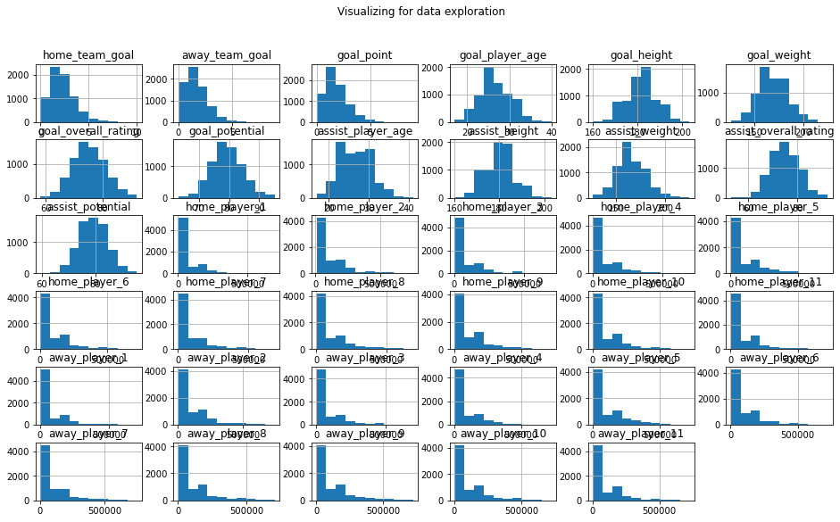

```python
import pylab as pl
df.hist(figsize = (16, 9));
pl.suptitle('Visualizing for data exploration'); # Not for the slide deck
```

```python
# variable categorizing

numeric_vars = ['home_team_goal', 'away_team_goal', 'goal_height', 'goal_player_age', 'goal_height', 'goal_weight', 'goal_overall_rating', 'goal_potential', 'assist_overall_rating', 'assist_potential', 'goal_point']
```

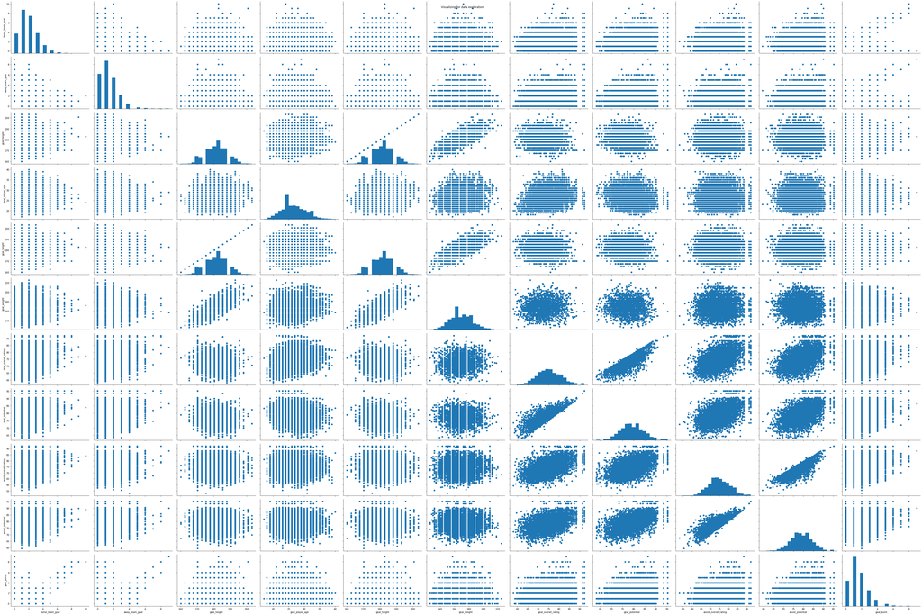

```python
g = sb.PairGrid(data = df, vars = numeric_vars, height = 3.5, aspect = 1.5);
g = g.map_diag(plt.hist, bins = 20);
g.map_offdiag(plt.scatter);
pl.suptitle('Visualizing for data exploration'); # Not for the slide deck
```

```python
df.corr()
```

|  | home_team_goal | away_team_goal | goal_point | goal_player_age | goal_height | goal_weight | goal_overall_rating | goal_potential | assist_player_age | assist_height | assist_weight | assist_overall_rating | assist_potential | home_player_1 | home_player_2 | home_player_3 | home_player_4 | home_player_5 | home_player_6 | home_player_7 | home_player_8 | home_player_9 | home_player_10 | home_player_11 | away_player_1 | away_player_2 | away_player_3 | away_player_4 | away_player_5 | … |
| --- | --- | --- | --- | --- | --- | --- | --- | --- | --- | --- | --- | --- | --- | --- | --- | --- | --- | --- | --- | --- | --- | --- | --- | --- | --- | --- | --- | --- | --- | --- |
| home_team_goal | 1.000000 | -0.226308 | 0.429955 | 0.017355 | -0.005330 | 0.004341 | 0.071515 | 0.061785 | 0.000526 | -0.013662 | 0.012508 | 0.065087 | 0.061609 | -0.020029 | -0.038896 | -0.025490 | -0.019752 | -0.041358 | -0.033357 | -0.022243 | -0.027645 | -0.028230 | -0.046937 | -0.033622 | 0.021333 | 0.014689 | 0.024932 | 0.017158 | 0.007520 | … |
| away_team_goal | -0.226308 | 1.000000 | 0.044003 | -0.023576 | 0.018827 | 0.012457 | 0.022713 | 0.030799 | -0.037462 | -0.013565 | -0.027929 | 0.001484 | 0.015981 | 0.019742 | 0.011963 | 0.016694 | 0.018546 | 0.041180 | 0.025636 | 0.000362 | 0.025273 | 0.015147 | 0.016841 | 0.036463 | -0.002769 | -0.016356 | -0.006091 | -0.009734 | -0.019160 | … |
| goal_point | 0.429955 | 0.044003 | 1.000000 | -0.004172 | 0.000825 | 0.009130 | 0.189790 | 0.201377 | -0.001281 | -0.017747 | -0.000427 | 0.195009 | 0.206672 | -0.017732 | -0.009858 | 0.000172 | -0.001408 | -0.019944 | -0.006978 | -0.001494 | -0.013167 | -0.000378 | -0.022538 | -0.010261 | 0.003571 | -0.001456 | 0.010085 | 0.005991 | 0.000635 | … |
| goal_player_age | 0.017355 | -0.023576 | -0.004172 | 1.000000 | 0.089946 | 0.162916 | 0.219615 | -0.154636 | 0.104633 | -0.004279 | 0.015103 | 0.038964 | -0.008391 | -0.022107 | -0.095927 | -0.077036 | -0.050701 | -0.075340 | -0.075944 | -0.083366 | -0.087186 | -0.104616 | -0.115418 | -0.147429 | -0.063654 | -0.081441 | -0.095043 | -0.059936 | -0.080475 | … |
| goal_height | -0.005330 | 0.018827 | 0.000825 | 0.089946 | 1.000000 | 0.744458 | -0.057127 | -0.100543 | 0.000630 | 0.030341 | 0.024879 | -0.019593 | -0.029306 | -0.013669 | -0.017087 | 0.000794 | -0.002291 | -0.029785 | -0.010456 | -0.026022 | -0.019881 | -0.004352 | 0.000787 | -0.012844 | -0.026555 | 0.004480 | -0.017828 | -0.029161 | -0.023691 | … |
| goal_weight | 0.004341 | 0.012457 | 0.009130 | 0.162916 | 0.744458 | 1.000000 | 0.051867 | -0.036667 | 0.019163 | 0.028235 | 0.046022 | 0.018801 | -0.007433 | -0.039265 | -0.069225 | -0.041621 | -0.025053 | -0.061201 | -0.059610 | -0.062719 | -0.062425 | -0.051712 | -0.052271 | -0.062005 | -0.059970 | -0.050136 | -0.064380 | -0.050935 | -0.057460 | … |
| goal_overall_rating | 0.071515 | 0.022713 | 0.189790 | 0.219615 | -0.057127 | 0.051867 | 1.000000 | 0.859870 | 0.044004 | -0.033882 | -0.002198 | 0.565428 | 0.517010 | -0.186411 | -0.245199 | -0.193962 | -0.186886 | -0.230524 | -0.224594 | -0.224019 | -0.244463 | -0.238509 | -0.263979 | -0.256560 | -0.189464 | -0.215382 | -0.211058 | -0.175000 | -0.232474 | … |
| goal_potential | 0.061785 | 0.030799 | 0.201377 | -0.154636 | -0.100543 | -0.036667 | 0.859870 | 1.000000 | 0.003660 | -0.037990 | -0.018917 | 0.516260 | 0.532517 | -0.115281 | -0.115114 | -0.091084 | -0.092333 | -0.119138 | -0.106014 | -0.113904 | -0.126888 | -0.102984 | -0.122360 | -0.102205 | -0.100822 | -0.084084 | -0.096849 | -0.071077 | -0.114588 | … |
| assist_player_age | 0.000526 | -0.037462 | -0.001281 | 0.104633 | 0.000630 | 0.019163 | 0.044004 | 0.003660 | 1.000000 | 0.063249 | 0.151466 | 0.230318 | -0.140899 | -0.059050 | -0.092195 | -0.087357 | -0.087812 | -0.084528 | -0.086321 | -0.088034 | -0.094869 | -0.105106 | -0.099693 | -0.115678 | -0.063313 | -0.068917 | -0.084252 | -0.058501 | -0.079860 | … |
| assist_height | -0.013662 | -0.013565 | -0.017747 | -0.004279 | 0.030341 | 0.028235 | -0.033882 | -0.037990 | 0.063249 | 1.000000 | 0.743710 | -0.071608 | -0.092771 | -0.024608 | -0.015914 | -0.020282 | -0.015823 | -0.014679 | -0.010450 | -0.022409 | -0.014367 | -0.018349 | -0.013386 | -0.010086 | -0.011157 | -0.032038 | -0.023383 | -0.017946 | -0.031581 | … |
| assist_weight | 0.012508 | -0.027929 | -0.000427 | 0.015103 | 0.024879 | 0.046022 | -0.002198 | -0.018917 | 0.151466 | 0.743710 | 1.000000 | 0.025265 | -0.050713 | -0.055204 | -0.067264 | -0.051899 | -0.051960 | -0.044574 | -0.054465 | -0.062207 | -0.054930 | -0.054634 | -0.046416 | -0.042233 | -0.039983 | -0.069434 | -0.054584 | -0.048509 | -0.050704 | … |
| assist_overall_rating | 0.065087 | 0.001484 | 0.195009 | 0.038964 | -0.019593 | 0.018801 | 0.565428 | 0.516260 | 0.230318 | -0.071608 | 0.025265 | 1.000000 | 0.860976 | -0.205480 | -0.257719 | -0.216402 | -0.207464 | -0.246605 | -0.249277 | -0.245453 | -0.253758 | -0.249215 | -0.254926 | -0.260606 | -0.203019 | -0.219625 | -0.211317 | -0.183889 | -0.234406 | … |
| assist_potential | 0.061609 | 0.015981 | 0.206672 | -0.008391 | -0.029306 | -0.007433 | 0.517010 | 0.532517 | -0.140899 | -0.092771 | -0.050713 | 0.860976 | 1.000000 | -0.114334 | -0.128986 | -0.095586 | -0.092833 | -0.125527 | -0.126431 | -0.131293 | -0.122957 | -0.105057 | -0.124423 | -0.117938 | -0.107707 | -0.093879 | -0.098311 | -0.082799 | -0.116330 | … |
| home_player_1 | -0.020029 | 0.019742 | -0.017732 | -0.022107 | -0.013669 | -0.039265 | -0.186411 | -0.115281 | -0.059050 | -0.024608 | -0.055204 | -0.205480 | -0.114334 | 1.000000 | 0.253155 | 0.298651 | 0.332877 | 0.295679 | 0.236311 | 0.275992 | 0.257887 | 0.254012 | 0.279069 | 0.260045 | 0.177097 | 0.221141 | 0.196732 | 0.202302 | 0.223647 | … |
| home_player_2 | -0.038896 | 0.011963 | -0.009858 | -0.095927 | -0.017087 | -0.069225 | -0.245199 | -0.115114 | -0.092195 | -0.015914 | -0.067264 | -0.257719 | -0.128986 | 0.253155 | 1.000000 | 0.296802 | 0.302199 | 0.301374 | 0.303254 | 0.310836 | 0.313798 | 0.303582 | 0.345115 | 0.322696 | 0.253357 | 0.303192 | 0.273357 | 0.264040 | 0.258373 | … |
| home_player_3 | -0.025490 | 0.016694 | 0.000172 | -0.077036 | 0.000794 | -0.041621 | -0.193962 | -0.091084 | -0.087357 | -0.020282 | -0.051899 | -0.216402 | -0.095586 | 0.298651 | 0.296802 | 1.000000 | 0.272699 | 0.273954 | 0.289916 | 0.278417 | 0.247196 | 0.304253 | 0.286130 | 0.286359 | 0.218223 | 0.238936 | 0.229340 | 0.232823 | 0.243536 | … |
| home_player_4 | -0.019752 | 0.018546 | -0.001408 | -0.050701 | -0.002291 | -0.025053 | -0.186886 | -0.092333 | -0.087812 | -0.015823 | -0.051960 | -0.207464 | -0.092833 | 0.332877 | 0.302199 | 0.272699 | 1.000000 | 0.290747 | 0.290778 | 0.276301 | 0.291862 | 0.325409 | 0.320921 | 0.301066 | 0.201758 | 0.240837 | 0.222983 | 0.241022 | 0.220727 | … |
| home_player_5 | -0.041358 | 0.041180 | -0.019944 | -0.075340 | -0.029785 | -0.061201 | -0.230524 | -0.119138 | -0.084528 | -0.014679 | -0.044574 | -0.246605 | -0.125527 | 0.295679 | 0.301374 | 0.273954 | 0.290747 | 1.000000 | 0.268251 | 0.266025 | 0.264175 | 0.312711 | 0.308503 | 0.310965 | 0.212492 | 0.244441 | 0.243354 | 0.235089 | 0.234535 | … |
| home_player_6 | -0.033357 | 0.025636 | -0.006978 | -0.075944 | -0.010456 | -0.059610 | -0.224594 | -0.106014 | -0.086321 | -0.010450 | -0.054465 | -0.249277 | -0.126431 | 0.236311 | 0.303254 | 0.289916 | 0.290778 | 0.268251 | 1.000000 | 0.283973 | 0.293661 | 0.295471 | 0.300690 | 0.289535 | 0.237843 | 0.264519 | 0.228169 | 0.258961 | 0.250594 | … |
| home_player_7 | -0.022243 | 0.000362 | -0.001494 | -0.083366 | -0.026022 | -0.062719 | -0.224019 | -0.113904 | -0.088034 | -0.022409 | -0.062207 | -0.245453 | -0.131293 | 0.275992 | 0.310836 | 0.278417 | 0.276301 | 0.266025 | 0.283973 | 1.000000 | 0.290090 | 0.277625 | 0.320483 | 0.284822 | 0.214036 | 0.274312 | 0.255671 | 0.235312 | 0.249260 | … |
| home_player_8 | -0.027645 | 0.025273 | -0.013167 | -0.087186 | -0.019881 | -0.062425 | -0.244463 | -0.126888 | -0.094869 | -0.014367 | -0.054930 | -0.253758 | -0.122957 | 0.257887 | 0.313798 | 0.247196 | 0.291862 | 0.264175 | 0.293661 | 0.290090 | 1.000000 | 0.316816 | 0.354263 | 0.310463 | 0.231898 | 0.285759 | 0.258458 | 0.238143 | 0.250428 | … |
| home_player_9 | -0.028230 | 0.015147 | -0.000378 | -0.104616 | -0.004352 | -0.051712 | -0.238509 | -0.102984 | -0.105106 | -0.018349 | -0.054634 | -0.249215 | -0.105057 | 0.254012 | 0.303582 | 0.304253 | 0.325409 | 0.312711 | 0.295471 | 0.277625 | 0.316816 | 1.000000 | 0.343589 | 0.320157 | 0.244532 | 0.302011 | 0.269123 | 0.265686 | 0.253619 | … |
| home_player_10 | -0.046937 | 0.016841 | -0.022538 | -0.115418 | 0.000787 | -0.052271 | -0.263979 | -0.122360 | -0.099693 | -0.013386 | -0.046416 | -0.254926 | -0.124423 | 0.279069 | 0.345115 | 0.286130 | 0.320921 | 0.308503 | 0.300690 | 0.320483 | 0.354263 | 0.343589 | 1.000000 | 0.333278 | 0.239147 | 0.305971 | 0.258709 | 0.257812 | 0.258153 | … |
| home_player_11 | -0.033622 | 0.036463 | -0.010261 | -0.147429 | -0.012844 | -0.062005 | -0.256560 | -0.102205 | -0.115678 | -0.010086 | -0.042233 | -0.260606 | -0.117938 | 0.260045 | 0.322696 | 0.286359 | 0.301066 | 0.310965 | 0.289535 | 0.284822 | 0.310463 | 0.320157 | 0.333278 | 1.000000 | 0.239989 | 0.293901 | 0.264454 | 0.240601 | 0.249043 | … |
| away_player_1 | 0.021333 | -0.002769 | 0.003571 | -0.063654 | -0.026555 | -0.059970 | -0.189464 | -0.100822 | -0.063313 | -0.011157 | -0.039983 | -0.203019 | -0.107707 | 0.177097 | 0.253357 | 0.218223 | 0.201758 | 0.212492 | 0.237843 | 0.214036 | 0.231898 | 0.244532 | 0.239147 | 0.239989 | 1.000000 | 0.247893 | 0.292041 | 0.345781 | 0.301377 | … |
| away_player_2 | 0.014689 | -0.016356 | -0.001456 | -0.081441 | 0.004480 | -0.050136 | -0.215382 | -0.084084 | -0.068917 | -0.032038 | -0.069434 | -0.219625 | -0.093879 | 0.221141 | 0.303192 | 0.238936 | 0.240837 | 0.244441 | 0.264519 | 0.274312 | 0.285759 | 0.302011 | 0.305971 | 0.293901 | 0.247893 | 1.000000 | 0.297057 | 0.283692 | 0.301176 | … |
| away_player_3 | 0.024932 | -0.006091 | 0.010085 | -0.095043 | -0.017828 | -0.064380 | -0.211058 | -0.096849 | -0.084252 | -0.023383 | -0.054584 | -0.211317 | -0.098311 | 0.196732 | 0.273357 | 0.229340 | 0.222983 | 0.243354 | 0.228169 | 0.255671 | 0.258458 | 0.269123 | 0.258709 | 0.264454 | 0.292041 | 0.297057 | 1.000000 | 0.276638 | 0.246548 | … |
| away_player_4 | 0.017158 | -0.009734 | 0.005991 | -0.059936 | -0.029161 | -0.050935 | -0.175000 | -0.071077 | -0.058501 | -0.017946 | -0.048509 | -0.183889 | -0.082799 | 0.202302 | 0.264040 | 0.232823 | 0.241022 | 0.235089 | 0.258961 | 0.235312 | 0.238143 | 0.265686 | 0.257812 | 0.240601 | 0.345781 | 0.283692 | 0.276638 | 1.000000 | 0.284636 | … |
| away_player_5 | 0.007520 | -0.019160 | 0.000635 | -0.080475 | -0.023691 | -0.057460 | -0.232474 | -0.114588 | -0.079860 | -0.031581 | -0.050704 | -0.234406 | -0.116330 | 0.223647 | 0.258373 | 0.243536 | 0.220727 | 0.234535 | 0.250594 | 0.249260 | 0.250428 | 0.253619 | 0.258153 | 0.249043 | 0.301377 | 0.301176 | 0.246548 | 0.284636 | 1.000000 | … |
| away_player_6 | -0.020176 | -0.003553 | -0.020417 | -0.085122 | -0.025166 | -0.070444 | -0.219191 | -0.095122 | -0.069419 | 0.002847 | -0.036791 | -0.237087 | -0.121547 | 0.233400 | 0.266870 | 0.252511 | 0.240544 | 0.251876 | 0.259976 | 0.255480 | 0.274264 | 0.284301 | 0.287452 | 0.286912 | 0.262596 | 0.289100 | 0.309439 | 0.277087 | 0.272777 | … |
| away_player_7 | 0.001423 | 0.015763 | 0.013852 | -0.072761 | -0.022661 | -0.052291 | -0.204537 | -0.099673 | -0.068333 | -0.045001 | -0.068596 | -0.227843 | -0.115224 | 0.231044 | 0.272525 | 0.241504 | 0.248507 | 0.263325 | 0.270169 | 0.229152 | 0.247106 | 0.293231 | 0.268112 | 0.275850 | 0.273936 | 0.326957 | 0.273748 | 0.290738 | 0.280308 | … |
| away_player_8 | -0.008890 | -0.002055 | -0.003246 | -0.066529 | 0.002343 | -0.042975 | -0.233704 | -0.126664 | -0.087714 | 0.001542 | -0.042822 | -0.247408 | -0.127467 | 0.230568 | 0.287283 | 0.281438 | 0.265652 | 0.265157 | 0.283253 | 0.251477 | 0.263745 | 0.304059 | 0.294932 | 0.275227 | 0.266284 | 0.288534 | 0.280165 | 0.316196 | 0.274982 | … |
| away_player_9 | 0.000440 | -0.008301 | -0.001057 | -0.111144 | -0.024218 | -0.066088 | -0.231926 | -0.088718 | -0.097388 | 0.014114 | -0.038884 | -0.250100 | -0.113922 | 0.273482 | 0.280462 | 0.293540 | 0.267441 | 0.261036 | 0.289305 | 0.255822 | 0.290582 | 0.309623 | 0.302778 | 0.288046 | 0.261929 | 0.306466 | 0.299425 | 0.310470 | 0.309906 | … |
| away_player_10 | 0.022364 | -0.022865 | 0.015938 | -0.107010 | -0.039644 | -0.083153 | -0.245103 | -0.107779 | -0.092607 | -0.017622 | -0.040850 | -0.242517 | -0.118771 | 0.234928 | 0.312538 | 0.259141 | 0.239421 | 0.261753 | 0.265458 | 0.275924 | 0.282440 | 0.269229 | 0.289443 | 0.280880 | 0.282096 | 0.331557 | 0.295483 | 0.310931 | 0.313899 | … |
| away_player_11 | 0.022787 | -0.011000 | 0.015876 | -0.111035 | -0.051495 | -0.088288 | -0.260758 | -0.124122 | -0.085948 | -0.028180 | -0.055447 | -0.259085 | -0.133961 | 0.238972 | 0.324702 | 0.249471 | 0.270112 | 0.261691 | 0.281969 | 0.274087 | 0.287464 | 0.290601 | 0.287559 | 0.284921 | 0.265624 | 0.331709 | 0.301211 | 0.301410 | 0.326596 | … |